# Reproducible research with RMarkdown

DEG analysis with DESeq2

Alen Lovric

20 April, 2026

#### Dependencies

Pipeline depends on the following packages: ‘tidyverse’, ‘DESeq2’, ‘DT’ and ‘ggrepel’. NOTE - in order to run Rmarkdown each package needs to be already installed in you R for pipeline to work.

```r
# Load required libraries
library(pacman)
p_load('tidyverse', 'DESeq2', 'DT', 'ggrepel')
```

#### 1. Load the Data

In this stage, we prepare the count matrix and metadata files. The count matrix contains raw gene expression counts across different samples, while the metadata file includes essential information such as sample identifiers, conditions, and covariates. Properly formatted input files are crucial for the subsequent analysis steps.

```r
# Load count matrix and metadata
counts <- read.delim(params$data_file)
metadata <- read.delim(params$metadata_file)

# Ensure metadata has row names matching samples
if (!all(colnames(counts) == rownames(metadata))) stop("Sample names don't match!!!")
```

#### 2. Preprocess and Setup DESeq2

Normalization is performed to account for systematic biases and technical variations across samples. We utilize methods like the DESeq2’s normalization procedure, which applies a size factor to each sample based on the geometric mean of counts, ensuring that the data is comparable across samples.

```r
# Convert condition column to a factor
metadata[[params$condition_column]] <- factor(metadata[[params$condition_column]],
    levels = c(params$control_group, params$treatment_group))

# Create DESeqDataSet
dds <- DESeqDataSetFromMatrix(countData = counts, colData = metadata,
    design = if (!is.null(params$covariate)) {
        as.formula(paste("~", params$covariate, "+", params$condition_column))
    } else {
        as.formula(paste("~", params$condition_column))
    })
```

#### 3. Differential Expression Analysis

In this phase, we identify differential expressed genes (DEGs) between the specified conditions. Using the DESeq2 package, we fit a generalized linear model to the count data and perform statistical tests to estimate the log2 fold change and adjusted p-values for each gene. This step highlights genes that exhibit significant changes in expression related to the conditions under study.

NOTE: Following steps are just for the purpose of this exercise. For more detailed examples and more comprehensive overview of DEA refer to [DESeq2 vignette](https://bioconductor.org/packages/devel/bioc/vignettes/DESeq2/inst/doc/DESeq2.html#indfilt).

```r
# Run DEA
dds <- DESeq(dds)

# Get results with specified thresholds
res <- results(dds, alpha = params$alpha, lfcThreshold = params$lfc_threshold)

# Order results by p-value
res <- res[order(res$padj), ]
res <- na.omit(res)

# Save results to file
write.csv(as.data.frame(res), file = file.path(params$output_dir, "DEG_results.csv"))
```

#### 4. Results Table

The results table presents the differential expressed genes (DEGs) identified through our analysis. Each row in the table corresponds to a specific gene, providing key metrics such as the gene name, base mean expression, log2 fold change, p-value and adjusted p-value.

```r
# Display the table with modified search functionality and a box around it
datatable(
  res %>% as.data.frame(.) %>%
    tibble::rownames_to_column(var = 'ensembl') %>%
    tibble::remove_rownames() %>%
    mutate_if(is.numeric, function(x) round(x, 3)),
  options = list(
    pageLength = 100,       # Number of rows to display per page
    scrollX = TRUE,         # Enable horizontal scrolling
    scrollY = "350px",      # Set table height
    autoWidth = FALSE,
    dom = '<"dt-header"f>t<"dt-footer"lip>'  # Custom layout: search box first, then entries dropdown
  ),
  rownames = FALSE
) %>%
  htmlwidgets::onRender("
    function(el) {
      $(el).css({
        'border': '2px solid #ccc',
        'border-radius': '5px',
        'overflow': 'hidden',  // to avoid overflow from rounded corners
        'margin-top': '50px',  // Space above the table
        'margin-bottom': '20px' // Space below the table
      });
    }
  ")
```

| ensembl | baseMean | log2FoldChange | lfcSE | stat | pvalue | padj |
| --- | --- | --- | --- | --- | --- | --- |
| ENSG00000260802 | 352.218 | 1.79 | 0.26 | 6.896 | 0 | 0 |
| ENSG00000141753 | 1005.363 | 1.065 | 0.214 | 4.979 | 0 | 0.001 |
| ENSG00000112379 | 1225.961 | -1.017 | 0.214 | -4.746 | 0 | 0.002 |
| ENSG00000197956 | 382.769 | 1.086 | 0.235 | 4.625 | 0 | 0.003 |
| ENSG00000064651 | 582.938 | -1.094 | 0.248 | -4.407 | 0 | 0.006 |
| ENSG00000137673 | 568.67 | 1.5 | 0.338 | 4.439 | 0 | 0.006 |
| ENSG00000049759 | 1825.888 | -0.895 | 0.21 | -4.26 | 0 | 0.006 |
| ENSG00000054690 | 1285.934 | -1.122 | 0.261 | -4.298 | 0 | 0.006 |
| ENSG00000124406 | 303.493 | -1.101 | 0.259 | -4.243 | 0 | 0.006 |
| ENSG00000139116 | 288.306 | -1.1 | 0.26 | -4.24 | 0 | 0.006 |

[output cut: 3174 more lines]

#### 5. Volcano Plot

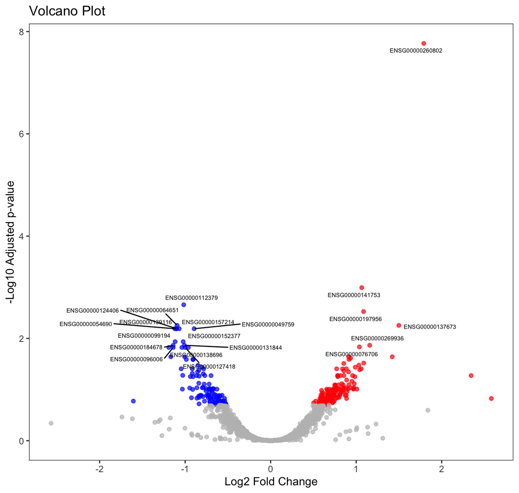

```r
if (params$plot_volcano) {
  res_df <- as.data.frame(res) %>%
    mutate(sig = case_when(padj < params$alpha & log2FoldChange > params$lfc_threshold ~ "Up",
                           padj < params$alpha & log2FoldChange < params$lfc_threshold ~ "Down",
                           TRUE ~ "No"))

  top_genes <- head(res, n = params$top_genes)

  ggplot(res_df, aes(x = log2FoldChange, y = -log10(padj), color = sig)) +
    geom_point(alpha = 0.7) +
    geom_text_repel(data = top_genes, aes(label = rownames(top_genes)),
                    color = 'black', size = 2, max.overlaps = Inf) +
    scale_color_manual(values = c("No" = "grey", "Up" = "red", 'Down' = 'blue')) +
    labs(title = "Volcano Plot", x = "Log2 Fold Change", y = "-Log10 Adjusted p-value") +
    theme_bw() +
    theme(legend.position = 'none',
          panel.grid = element_blank())

  # Convert ggplot to plotly for interactivity
  # ggplotly(p)
}
```